# Lab 3 Extending Logistic Regression —— The Quality of Red Wines

47491968 Yuankai Liu  
47511663 Jianing Zhao  
47564911 Yang Peng

# 1. Preparation and Overview

## 1.1 Business understanding

In this lab, The dataset is related the Portuguese "Vinho Verde" red wine. The inputs include objective tests (e.g. PH values) and the output is based on sensory data(median of at least 3 evaluations made by wine experts). Each expert graded the wine quality between 0 (very bad) and 10 (very excellent). We know that many points of view are needed to be considered to describe the quality of red wines. When winery produced batches of red wines and wanted to put them into market, how to set the price of these red wine becomes a problem, despite the fact that they may have a traditional way. Also, When customers want to buy red wines, how to buy good quality of red wines is puzzling.

Therefore, finding a quick and effective way to judge the quality of red wine is meaningful. We will use physicochemical properties to explore a effective method to describe the quality of red wines. We think if this standard can be accurate more than 90%, it can be popular in the field of red wine, and if this standard can be accurate more than 60%, it can serve as a reference in the field of red wine. Both winery and customers will be interested in this results. Because it can not only help the winery set the price scientifically, but also help customers buy best red wines with limited money.

The classification task is to use acid, sugar, chlorides, sulfur, density, ph, suliphates, alcohol to make a logistic regression classifier by machine learning to classify those different quality of red wines.

## 1.2 Define and prepare your class variables

This dataset has 12 variables and all variables are numerical. There are 1599 rows of instances and there is no missing data in this dataset.

Because we want to classify the different quality of red wines, first we should remove the column of quality and then make matrix representation. After doing those processes, the data can be used for classification. When we get the results of classification, we will compute the accuracy to verify the performance of this model.

```python
import numpy as np
import pandas as pd
from sklearn.cross_validation import train_test_split
from sklearn.metrics import accuracy_score
df=pd.read_csv('redwine.csv')
df.shape
y=df['quality']
y=y-3
X= df.drop(['quality'],axis=1)
Xm=np.array(X)
ym=np.array(y)

print(df.info())
```

```
<class 'pandas.core.frame.DataFrame'>
RangeIndex: 1599 entries, 0 to 1598
Data columns (total 12 columns):
fixed acidity           1599 non-null float64
volatile acidity        1599 non-null float64
citric acid             1599 non-null float64
residual sugar          1599 non-null float64
chlorides               1599 non-null float64
free sulfur dioxide     1599 non-null float64
total sulfur dioxide    1599 non-null float64
density                 1599 non-null float64
pH                      1599 non-null float64
sulphates               1599 non-null float64
alcohol                 1599 non-null float64
quality                 1599 non-null int64
dtypes: float64(11), int64(1)
memory usage: 150.0 KB
None
```

```python
df.head()
```

|  | fixed acidity | volatile acidity | citric acid | residual sugar | chlorides | free sulfur dioxide | total sulfur dioxide | density | pH | sulphates | alcohol | quality |
| --- | --- | --- | --- | --- | --- | --- | --- | --- | --- | --- | --- | --- |
| 0 | 7.4 | 0.70 | 0.00 | 1.9 | 0.076 | 11.0 | 34.0 | 0.9978 | 3.51 | 0.56 | 9.4 | 5 |
| 1 | 7.8 | 0.88 | 0.00 | 2.6 | 0.098 | 25.0 | 67.0 | 0.9968 | 3.20 | 0.68 | 9.8 | 5 |
| 2 | 7.8 | 0.76 | 0.04 | 2.3 | 0.092 | 15.0 | 54.0 | 0.9970 | 3.26 | 0.65 | 9.8 | 5 |
| 3 | 11.2 | 0.28 | 0.56 | 1.9 | 0.075 | 17.0 | 60.0 | 0.9980 | 3.16 | 0.58 | 9.8 | 6 |
| 4 | 7.4 | 0.70 | 0.00 | 1.9 | 0.076 | 11.0 | 34.0 | 0.9978 | 3.51 | 0.56 | 9.4 | 5 |

## 1.3 Training and testing set dividing

Divide the data into training and testing data using an 80% training and 20% testing split.

```python
#X= X.drop(['density'],axis=1)
X_train, X_test, y_train, y_test = train_test_split(Xm, ym, test_size=0.2)

print(X_train.shape)
print(X_test.shape)
```

```
(1279, 11)
(320, 11)
```

We create the model by using the training set, so we can not use the training set to verify the performance of the model. Therefore, spliting the data using an 80/20 split is the right way for us to do classification, the results in the test set are the verification of performance of the model.

# 2. Modeling

## 2.1 Creating the classifier

Create a custom, one-versus-all logistic regression classifier using numpy and scipy to optimize.

```python
import numpy as np
class BinaryLogisticRegressionBase:
    # private:
    def __init__(self, eta, iterations=20):
        self.eta = eta
        self.iters = iterations
        # internally we will store the weights as self.w_ to keep with sklearn conventions

    def __str__(self):
        return 'Base Binary Logistic Regression Object, Not Trainable'

    # convenience, private:
    @staticmethod
    def _sigmoid(theta):
        return expit(theta)

    @staticmethod
    def _add_bias(X):
        return np.hstack((np.ones((X.shape[0],1)),X)) # add bias term

    # public:
    def predict_proba(self,X,add_bias=True):
        # add bias term if requested
        Xb = self._add_bias(X) if add_bias else X
        return self._sigmoid(Xb @ self.w_) # return the probability y=1

    def predict(self,X):
        return (self.predict_proba(X)>0.5) #return the actual prediction



blr = BinaryLogisticRegressionBase(0.1)
print(blr)
```

```
Base Binary Logistic Regression Object, Not Trainable
```

Here we added steepest descent method, stochastic gradient descent method, and Newton's method to the logistic regression classifier. The type of optimization technique is controlled by 'Cc'.

0 - Steepest descent method

1 - Stochastic gradient descent method

2 - Newton's method

```python
from scipy.optimize import fmin_bfgs
from numpy.linalg import pinv
class BinaryLogisticRegression(BinaryLogisticRegressionBase):
    #private:
    def __str__(self):
        if(hasattr(self,'w_')):
            return 'Binary Logistic Regression Object with coefficients:\n'+ str(self.w_) # is we have trained the object
        else:
            return 'Untrained Binary Logistic Regression Object'

    @staticmethod
    def objective_function(w,X,y,C):
        g = expit(X @ w)
        return -np.sum(np.log(g[y==1]))-np.sum(np.log(1-g[y==0])) + C*sum(w**2) #-np.sum(y*np.log(g)+(1-y)*np.log(1-g))

    @staticmethod
    def objective_gradient(w,X,y,C):
        g = expit(X @ w)
        ydiff = y-g # get y difference
        gradient = np.mean(X * ydiff[:,np.newaxis], axis=0)
        gradient = gradient.reshape(w.shape)
        gradient[1:] += -2 * w[1:] * C
        return -gradient

    def _get_gradient(self,X,y,Cc):
        if Cc==0:
            # programming \sum_i (yi-g(xi))xi
            gradient = np.zeros(self.w_.shape) # set gradient to zero
            for (xi,yi) in zip(X,y):
                # the actual update inside of sum
                gradi = (yi - self.predict_proba(xi,add_bias=False))*xi
                # reshape to be column vector and add to gradient
                gradient += gradi.reshape(self.w_.shape)
            return gradient/float(len(y))

        elif Cc==1:
            gradient = np.zeros(self.w_.shape) # set gradient to zero

            # the actual update inside of sum
            num_samples, num_features = X.shape
            i=np.random.randint(0, num_samples)
            gradi = (y[i]*1 - self.predict_proba(X[i],add_bias=False))*X[i]
           # reshape to be column vector and add to gradient
            return gradi.reshape(self.w_.shape)

        elif Cc==2:
            g = self.predict_proba(X,add_bias=False).ravel() # get sigmoid value for all classes
            hessian = X.T @ np.diag(g*(1-g)) @ X - 2 * self.C # calculate the hessian
            ydiff = y-g # get y difference
            gradient = np.sum(X * ydiff[:,np.newaxis], axis=0) # make ydiff a column vector and multiply through
            gradient = gradient.reshape(self.w_.shape)
            return pinv(hessian) @ gradient



    # public:
    def fit(self, X, y,Cc):
        Xb = self._add_bias(X) # add bias term
        num_samples, num_features = Xb.shape
        self.w_ = np.zeros((num_features,1)) # init weight vector to zeros
        # for as many as the max iterations
        for _ in range(self.iters):
            gradient = self._get_gradient(Xb,y,Cc)
            self.w_ += gradient*self.eta # multiply by learning rate
```

Make BinaryLogisticRegression to one-versus-all LogisticRegression.

```python
class LogisticRegression:
    def __init__(self, eta, iterations=20):
        self.eta = eta
        self.iters = iterations
        # internally we will store the weights as self.w_ to keep with sklearn conventions

    def __str__(self):
        if(hasattr(self,'w_')):
            return 'MultiClass Logistic Regression Object with coefficients:\n'+ str(self.w_) # is we have trained the object
        else:
            return 'Untrained MultiClass Logistic Regression Object'

    def fit(self,X,y,Cc):
        num_samples, num_features = X.shape
        self.unique_ = np.unique(y) # get each unique class value
        num_unique_classes = len(self.unique_)
        self.classifiers_ = [] # will fill this array with binary classifiers

        for i,yval in enumerate(self.unique_): # for each unique value
            y_binary = y==yval # create a binary problem
            # train the binary classifier for this class
            blr = BinaryLogisticRegression(self.eta,self.iters)
            blr.fit(X,y_binary,Cc)
            # add the trained classifier to the list
            self.classifiers_.append(blr)

        # save all the weights into one matrix, separate column for each class
        self.w_ = np.hstack([x.w_ for x in self.classifiers_]).T

    def predict_proba(self,X):
        probs = []
        for blr in self.classifiers_:
            probs.append(blr.predict_proba(X)) # get probability for each classifier

        return np.hstack(probs) # make into single matrix

    def predict(self,X):
        return np.argmax(self.predict_proba(X),axis=1) # take argmax along row
```

Here we updated the gradient calculation to include a customizable regularization term. The type of regularization is controlled by 'Lc'.

```python
class RegularizedBinaryLogisticRegression(BinaryLogisticRegression):
    # extend init functions
    def __init__(self, C=0.0, **kwds):
        # need to add to the original initializer
        self.C = C
        # but keep other keywords
        super().__init__(**kwds) # call parent initializer

    def sgn(v):
        if v>=0:
            return 1
        else:
            return -1
    # extend previous class to change functionality
    def _get_gradient(self,X,y,Cc,Lc=0):
        # call get gradient from previous class
        gradient = super()._get_gradient(X,y,Cc)
        if Lc==0:
            return gradient
        elif Lc==1:
            w2 = np.zeros((X.shape[1],1))
            for i in range(w2.shape[0]):
                w2[i]=sgn(self.w_[i])
            gradient[1:]+= -2 * w2[1:] * self.C
            return gradient
        elif Lc==2:
        # add in regularization (to all except bias term)
            gradient[1:] += -2 * self.w_[1:] * self.C
            return gradient
        elif Lc==3:

            w2 = np.zeros((X.shape[1],1))
            for i in range(w2.shape[0]):
                w2[i]=sgn(self.w_[i])
            gradient[1:]+=-2 * self.w_[1:] * self.C-2 * w2[1:]*self.C
            return gradient
    def fit(self, X, y,Cc,Lc):
        Xb = self._add_bias(X) # add bias term
        num_samples, num_features = Xb.shape
        self.w_ = np.zeros((num_features,1)) # init weight vector to zeros
        # for as many as the max iterations
        for _ in range(self.iters):
            gradient = self._get_gradient(Xb,y,Cc)
            self.w_ += gradient*self.eta # multiply by learning rate
```

Make RegularizedBinaryLogisticRegression to one-versus-all RegularizedLogisticRegression.

```python
class RegularizedLogisticRegression(LogisticRegression):
    def __init__(self, C=0.0, **kwds):
        # need to add to the original initializer
        self.C = C
        # but keep other keywords
        super().__init__(**kwds) # call parent initializer



    def fit(self,X,y,Cc,Lc):
        num_samples, num_features = X.shape
        self.unique_ = np.unique(y) # get each unique class value
        num_unique_classes = len(self.unique_)
        self.classifiers_ = [] # will fill this array with binary classifiers

        for i,yval in enumerate(self.unique_): # for each unique value
            y_binary = y==yval # create a binary problem
            # train the binary classifier for this class
            blr = RegularizedBinaryLogisticRegression(eta=self.eta,
                                                      iterations=self.iters,
                                                      C=self.C)
            blr.fit(X,y_binary,Cc,Lc)
            # add the trained classifier to the list
            self.classifiers_.append(blr)

        # save all the weights into one matrix, separate column for each class
        self.w_ = np.hstack([x.w_ for x in self.classifiers_]).T
```

## 2.2 Training the classifier

Train the classifier to achieve good generalization performance. Adjust the optimization technique 'Cc' and the value of the regularization term 'Lc' to achieve the best performance on the test set.

Steepest descent method

```python
%%time
params=dict(eta=0.001,iterations=500,C=0.01)
blr=RegularizedLogisticRegression(**params)
blr.fit(X_train,y_train,Cc=0,Lc=1)
yhat=blr.predict(X_train)
yhat_test=blr.predict(X_test)
print('Accuracy of traning set',params,accuracy_score(y_train,yhat))
print('Accuracy of testing set',params,accuracy_score(y_test,yhat_test))
```

```
Accuracy of traning set {'eta': 0.001, 'iterations': 500, 'C': 0.01} 0.505082095387
Accuracy of testing set {'eta': 0.001, 'iterations': 500, 'C': 0.01} 0.490625
Wall time: 18.4 s
```

```python
%%time
params=dict(eta=0.001,iterations=500,C=0.01)
blr=RegularizedLogisticRegression(**params)
blr.fit(X_train,y_train,Cc=0,Lc=1)
yhat=blr.predict(X_train)
yhat_test=blr.predict(X_test)
print('Accuracy of traning set',params,accuracy_score(y_train,yhat))
print('Accuracy of testing set',params,accuracy_score(y_test,yhat_test))
```

```
Accuracy of traning set {'eta': 0.001, 'iterations': 500, 'C': 0.01} 0.505082095387
Accuracy of testing set {'eta': 0.001, 'iterations': 500, 'C': 0.01} 0.490625
Wall time: 18.3 s
```

```python
%%time
params=dict(eta=0.001,iterations=500,C=0.01)
blr=RegularizedLogisticRegression(**params)
blr.fit(X_train,y_train,Cc=0,Lc=2)
yhat=blr.predict(X_train)
yhat_test=blr.predict(X_test)
print('Accuracy of traning set',params,accuracy_score(y_train,yhat))
print('Accuracy of testing set',params,accuracy_score(y_test,yhat_test))
```

```
Accuracy of traning set {'eta': 0.001, 'iterations': 500, 'C': 0.01} 0.505082095387
Accuracy of testing set {'eta': 0.001, 'iterations': 500, 'C': 0.01} 0.490625
Wall time: 18.5 s
```

```python
%%time
params=dict(eta=0.001,iterations=500,C=0.01)
blr=RegularizedLogisticRegression(**params)
blr.fit(X_train,y_train,Cc=0,Lc=3)
yhat=blr.predict(X_train)
yhat_test=blr.predict(X_test)
print('Accuracy of traning set',params,accuracy_score(y_train,yhat))
print('Accuracy of testing set',params,accuracy_score(y_test,yhat_test))
```

```
Accuracy of traning set {'eta': 0.001, 'iterations': 500, 'C': 0.01} 0.507427677873
Accuracy of testing set {'eta': 0.001, 'iterations': 500, 'C': 0.01} 0.490625
Wall time: 18.7 s
```

```python
time=[]
acctrain=[]
acctest=[]
time.append(18.7)
acctrain.append(0.5074)
acctest.append(0.4906)
```

Stochastic gradient descent method

```python
%%time
params=dict(eta=0.001,iterations=50000,C=0.01)
blr=RegularizedLogisticRegression(**params)
blr.fit(X_train,y_train,Cc=1,Lc=0)
yhat=blr.predict(X_train)
yhat_test=blr.predict(X_test)
print('Accuracy of traning set',params,accuracy_score(y_train,yhat))
print('Accuracy of testing set',params,accuracy_score(y_test,yhat_test))
```

```
Accuracy of traning set {'eta': 0.001, 'iterations': 50000, 'C': 0.01} 0.52853792025
Accuracy of testing set {'eta': 0.001, 'iterations': 50000, 'C': 0.01} 0.46875
Wall time: 3.48 s
```

```python
%%time
params=dict(eta=0.001,iterations=50000,C=0.001)
blr=RegularizedLogisticRegression(**params)
blr.fit(X_train,y_train,Cc=1,Lc=1)
yhat=blr.predict(X_train)
yhat_test=blr.predict(X_test)
print('Accuracy of traning set',params,accuracy_score(y_train,yhat))
print('Accuracy of testing set',params,accuracy_score(y_test,yhat_test))
```

```
Accuracy of traning set {'eta': 0.001, 'iterations': 50000, 'C': 0.001} 0.376856919468
Accuracy of testing set {'eta': 0.001, 'iterations': 50000, 'C': 0.001} 0.321875
Wall time: 3.5 s
```

```python
%%time
params=dict(eta=0.001,iterations=60000,C=0.001)
blr=RegularizedLogisticRegression(**params)
blr.fit(X_train,y_train,Cc=1,Lc=2)
yhat=blr.predict(X_train)
yhat_test=blr.predict(X_test)
print('Accuracy of traning set',params,accuracy_score(y_train,yhat))
print('Accuracy of testing set',params,accuracy_score(y_test,yhat_test))
```

```
Accuracy of traning set {'eta': 0.001, 'iterations': 60000, 'C': 0.001} 0.518373729476
Accuracy of testing set {'eta': 0.001, 'iterations': 60000, 'C': 0.001} 0.521875
Wall time: 4.19 s
```

```python
%%time
params=dict(eta=0.001,iterations=50000,C=0.01)
blr=RegularizedLogisticRegression(**params)
blr.fit(X_train,y_train,Cc=1,Lc=3)
yhat=blr.predict(X_train)
yhat_test=blr.predict(X_test)
print('Accuracy of traning set',params,accuracy_score(y_train,yhat))
print('Accuracy of testing set',params,accuracy_score(y_test,yhat_test))
```

```
Accuracy of traning set {'eta': 0.001, 'iterations': 50000, 'C': 0.01} 0.498045347928
Accuracy of testing set {'eta': 0.001, 'iterations': 50000, 'C': 0.01} 0.54375
Wall time: 3.51 s
```

```python
time.append(3.51)
acctrain.append(0.50)
acctest.append(0.54)
```

Newton's method

```python
%%time
params=dict(eta=0.001,iterations=3,C=0.01)
blr=RegularizedLogisticRegression(**params)
blr.fit(X_train,y_train,Cc=2,Lc=0)
yhat=blr.predict(X_train)
yhat_test=blr.predict(X_test)
print('Accuracy of traning set',params,accuracy_score(y_train,yhat))
print('Accuracy of testing set',params,accuracy_score(y_test,yhat_test))
```

```
Accuracy of traning set {'eta': 0.001, 'iterations': 3, 'C': 0.01} 0.586395621579
Accuracy of testing set {'eta': 0.001, 'iterations': 3, 'C': 0.01} 0.6
Wall time: 73.2 ms
```

```python
%%time
params=dict(eta=0.1,iterations=3,C=0.001)
blr=RegularizedLogisticRegression(**params)
blr.fit(X_train,y_train,Cc=2,Lc=1)
yhat=blr.predict(X_train)
yhat_test=blr.predict(X_test)
print('Accuracy of traning set',params,accuracy_score(y_train,yhat))
print('Accuracy of testing set',params,accuracy_score(y_test,yhat_test))
```

```
Accuracy of traning set {'eta': 0.1, 'iterations': 3, 'C': 0.001} 0.587959343237
Accuracy of testing set {'eta': 0.1, 'iterations': 3, 'C': 0.001} 0.6
Wall time: 70.2 ms
```

```python
%%time
params=dict(eta=0.001,iterations=3,C=0.0001)
blr=RegularizedLogisticRegression(**params)
blr.fit(X_train,y_train,Cc=2,Lc=2)
yhat=blr.predict(X_train)
yhat_test=blr.predict(X_test)
print('Accuracy of traning set',params,accuracy_score(y_train,yhat))
print('Accuracy of testing set',params,accuracy_score(y_test,yhat_test))
```

```
Accuracy of traning set {'eta': 0.001, 'iterations': 3, 'C': 0.0001} 0.587959343237
Accuracy of testing set {'eta': 0.001, 'iterations': 3, 'C': 0.0001} 0.603125
Wall time: 72.2 ms
```

```python
%%time
params=dict(eta=0.01,iterations=3,C=0.1)
blr=RegularizedLogisticRegression(**params)
blr.fit(X_train,y_train,Cc=2,Lc=3)
yhat=blr.predict(X_train)
yhat_test=blr.predict(X_test)
print('Accuracy of traning set',params,accuracy_score(y_train,yhat))
print('Accuracy of testing set',params,accuracy_score(y_test,yhat_test))
```

```
Accuracy of traning set {'eta': 0.01, 'iterations': 3, 'C': 0.1} 0.574667709148
Accuracy of testing set {'eta': 0.01, 'iterations': 3, 'C': 0.1} 0.590625
Wall time: 73.2 ms
```

```python
time.append(0.0722)
acctrain.append(0.588)
acctest.append(0.603)
```

```python
print(time)
print(acctrain)
print(acctest)
```

```
[18.7, 3.51, 0.0722]
[0.5074, 0.5, 0.588]
[0.4906, 0.54, 0.603]
```

```
Text(0.5,1,'Runing time of three optimization')
```

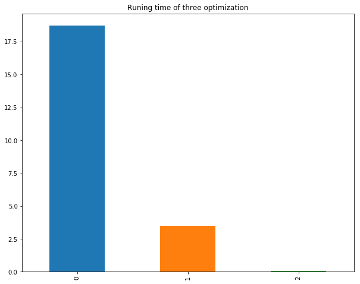

```python
import matplotlib.pyplot as plt

c={"time" : time,
   "acctrain" : acctrain,
   "acctest":acctest}
d=pd.DataFrame(c)
plt.figure(figsize=(10,8))
ax =d.time.plot(kind='bar')
plt.title('Runing time of three optimization')
```

```
Text(0.5,1,'Accuracy of training set of three optimization method')
```

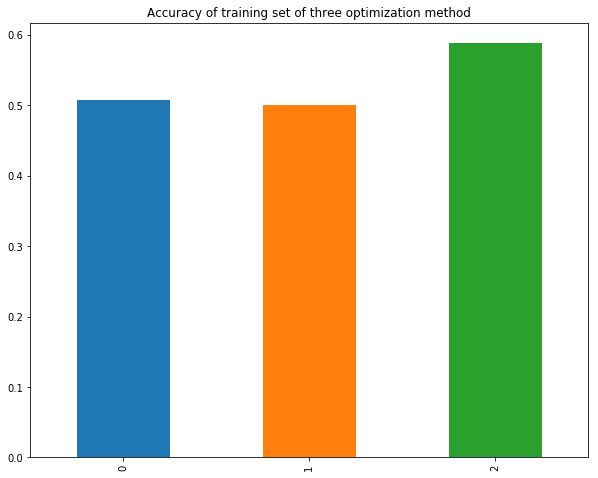

```python
plt.figure(figsize=(10,8))
ax =d.acctrain.plot(kind='bar')
plt.title('Accuracy of training set of three optimization method')
```

[output not shown]

[figure not shown]

```python
plt.figure(figsize=(10,8))
ax =d.acctest.plot(kind='bar')
plt.title('Accuracy of test set of three optimization method')
```

We tried many value of regularization term 'Lc' and the step length, and found the best result in each method. Then we made some histograms to show the results. From the visualizations, we can see that the best method is Newton's method with L2 regularization, it has both the highest accuracy and the fastest speed.

## 2.3 Comparation

Compare the performance of our classifier to the procedure used in scikit-learn.

Use scikit-learn to make the lpgistic regression.

```python
%%time
from sklearn.linear_model import LogisticRegression as SKLogisticRegression

rw = SKLogisticRegression()

rw.fit(X_train,y_train)

yhat = rw.predict(X_train)
print('Accuracy of: ',accuracy_score(y_train,yhat))
yhat_test = rw.predict(X_test)
print('Accuracy of :',accuracy_score(y_test,yhat_test))
```

```
Accuracy of:  0.586395621579
Accuracy of : 0.584375
Wall time: 21.1 ms
```

```
Text(0.5,1,'Running time')
```

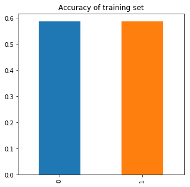

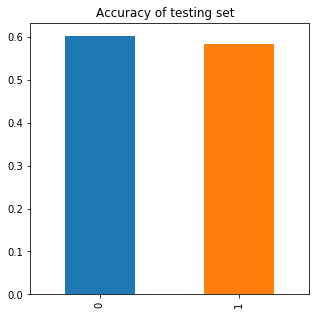

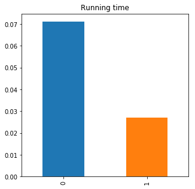

```python
c2={"time" : [0.0712,0.0271],
   "acctrain" :[0.588,0.586],
   "acctest":[0.603,0.584]}
d2=pd.DataFrame(c2)
plt.figure(figsize=(5,5))
ax =d2.acctrain.plot(kind='bar')
plt.title('Accuracy of training set')
plt.figure(figsize=(5,5))
ax =d2.acctest.plot(kind='bar')
plt.title('Accuracy of testing set  ')
plt.figure(figsize=(5,5))
ax =d2.time.plot(kind='bar')
plt.title('Running time')
```

0 represents our function and 1 represents Sklearn function.

We can see that my function's accuracy of training set and testing set is higher than Sklearn function. But the time wastes more. We think there are a lot of place to improve to reduce the time wasting.

# 3 Deployment

In this lab, we created a custom, one-versus-all logistic regression classifier using numpy and scipy. The classfier has three methods and four optimization techniques, so there are many kinds of combinations between each other. After verifing these procedures, finally we find the best procedure is Newton's methods with L2 regularization.

Compared to the procedure of scikit-learn, I would advise scikit-learn to be used in a deployed machine learning model. Our medol waste a lot of time, we didn't make the best optimizations and maybe there are better optimization techniques that we don't learn.

The reason is that the accuracy of scikit-learn is close to the results of our custom classifier, but the time of scikit-learn is obviously shorter than the time of our custom classifier.

In this lab, we only have 1599 instances and 12 variables. However, in the actual business analysis，there will be huge of data, accuracy is important, but the efficiency of model is very critical.

Besides, we mentioned before that if this standard can be accurate more than 90%, it can be popular in the field of red wine, and if this standard can be accurate more than 60%, it can serve as a reference in the field of red wine. Either the results of our method or the results of scikit-learn is just about 60%, so we can only use this physicochemical properties' classification as a reference to enhance the understanding of red wine.

# 4 Exceptional Work

```python
y_trains = (y_train>=3).astype(np.int)
from sklearn.linear_model import LinearRegression
L=LinearRegression()
L.fit(X_train,y_trains)
yp=L.predict(X_train)
yhat=1 / (1 + np.exp(-yp))
y_h = (yhat>=0.5).astype(np.int)
print('model coefficients are:', L.coef_)
print('Percentage accuracy:', float(sum(y_h==y_trains)) / len(y_trains))
```

```
model coefficients are: [  2.00754325e-02  -5.46874336e-01  -1.42416246e-01   7.92057768e-03
  -7.48812927e-01   4.32626752e-03  -3.19245729e-03  -9.88396902e+00
  -1.15665569e-01   5.36308772e-01   1.43361514e-01]
Percentage accuracy: 0.5465207193119624
```

Actually, we tried our best to comprehend the method you mentioned that you should use MSE as the object function. We only find that some mean square error user cases are in linear regression and neural networks, and we haven't come into contact with neural networks domian. We find that LinearRegression has a MSE caculation function and can do binary classify, so we tried to use it and finally found that the result was not very satisfied.